# Cyclistic Analysis

Peter Martin

2022-09-17

## Cyclstic Data Analysis (Google Data Analytics Certificate Case Study)

This notebook documents the data preparation and analysis of data provided for Cyclstic Case Study within my Google Data Analyst Case Study, final part. See this link for information on the course: https://www.coursera.org/professional-certificates/google-data-analytics

## Cyclistic Bikehire

Based in Chicago, Cyclstic looks to grow the company’s revenue by attracting its casual users to become members, paying an annual subscription for access to the service.

### Business Task

*What marketing activities should be undertaken to convert casual riders to members on an annual subscription.

### Data Files

The data files provided included 40 different files covering the last 8 years of cycle hires. From these it was necessary to only look at the last 12 months of data (Period Sept 2021 - Aug 2022) to review patterns in te data revealing the differences in behaviours of casual riders vs members.

The list of files used:

```r
202109-divvy-tripdata.csv
202110-divvy-tripdata.csv
202111-divvy-tripdata.csv
202112-divvy-tripdata.csv
202201-divvy-tripdata.csv
202202-divvy-tripdata.csv
202203-divvy-tripdata.csv
202204-divvy-tripdata.csv
202205-divvy-tripdata.csv
202206-divvy-tripdata.csv
202207-divvy-tripdata.csv
202208-divvy-tripdata.csv
```

A sample of the first data file showing the format of the raw CSV data and headers:

```r
ride_id,rideable_type,started_at,ended_at,start_station_name,start_station_id,end_station_name,end_station_id,start_lat,start_lng,end_lat,end_lng,member_casual
9DC7B962304CBFD8,electric_bike,2021-09-28 16:07:10,2021-09-28 16:09:54,,,,,41.89,-87.68,41.89,-87.67,casual
F930E2C6872D6B32,electric_bike,2021-09-28 14:24:51,2021-09-28 14:40:05,,,,,41.94,-87.64,41.98,-87.67,casual
6EF72137900BB910,electric_bike,2021-09-28 00:20:16,2021-09-28 00:23:57,,,,,41.81,-87.72,41.8,-87.72,casual
78D1DE133B3DBF55,electric_bike,2021-09-28 14:51:17,2021-09-28 15:00:06,,,,,41.8,-87.72,41.81,-87.72,casual

....

This is one of the 12 above listed files.  This file contained 756,149 lines of data
```

## Data Preparation and Cleaning

### R libraries used

To prepare, clean and analyze the data the following r libraries have been used.

```r
library(tidyverse)
```

```r
library(ggplot2)
library(ggmap)
library(lubridate)
library(viridis)
library(kableExtra)
```

In preparation for analyzing the data, the following steps were taken. 1. load all data files into a single tibble 2. review & amend datatypes assigned to each attribute

### Loading datafiles into a single tibble

```r
#set working directory
setwd("d:/personal/professional/Google data analyst cert/cyclistic datasets/current_data")

#create a vector of all the filenames
datafiles <- c(paste(2021,str_pad(9:12, 2, pad="0"),"-divvy-tripdata.csv",sep=""),
               paste(2022,str_pad(1:8, 2, pad="0"),"-divvy-tripdata.csv",sep=""))

#check this again

#create the hires tibble to read the CSV file contents
hires <- data.frame()
for (f in datafiles){
  hires <- rbind (hires, read.csv(f))
}
```

### Tidying the data

#### Converting character attributes to factors

Upon inspecting the loaded dataset, it is clear that some character attributes have a limited set of values; they may be candidates to be converted to a factor datatype, allowing more efficient manipulation: 1. rideable_type 2. member_casual

#### Parsing datetime data

Fields containing datetime data are also parsed to POSIXct datatypes to facilitate appropriate calculations of duration and identifying patterns of when casual riders are most active users of the service across the day, week and calendar year. The timezone “America/Chicago” has been selected based on the business context.

```r
#clean datatypes - factors for rideable_type and member_casual
#                - POSIXct (datetime) for started_at and ended_at
hires <- hires %>%
  mutate(rideable_type = as.factor(rideable_type),
         member_casual=as.factor(member_casual),
         hire_date= as.POSIXct(started_at, format = "%Y-%m-%d %H:%M:%S", tz = "America/Chicago"),
         return_date= as.POSIXct(ended_at, format = "%Y-%m-%d %H:%M:%S", tz = "America/Chicago"),
         start_station_name = as.factor(start_station_name)
         )
```

### Additional attributes added

Additional attributes were added to allow analysis and aggregation of the hires based on: 1. Duration of the hire (measured in minutes) 2. The month of the hire 3. The day of the week of the hire

```r
#calculate hire duration in minutes
hires$mins_hired = difftime(hires$return_date, hires$hire_date, units="mins")

#separate out by month to allow grouping by month
hires$hired_year_month = format(hires$hire_date, "%Y-%m")

#add in day of the week hired
hires$weekday = ordered(weekdays(hires$hire_date), levels=c("Sunday", "Monday", "Tuesday", "Wednesday", "Thursday", "Friday", "Saturday"))

#add in the hour when hire started
hires$start_hour = as.integer(format(hires$hire_date, "%H"))
```

### Differences between member and casual riders

A key line of enquiry was to identify the differences between the members and the casual riders.

The following charts identify: 1. Casual riders are more likely to hire an electric bike compared to a classic bike 2. Casual riders also make use of the docked bike

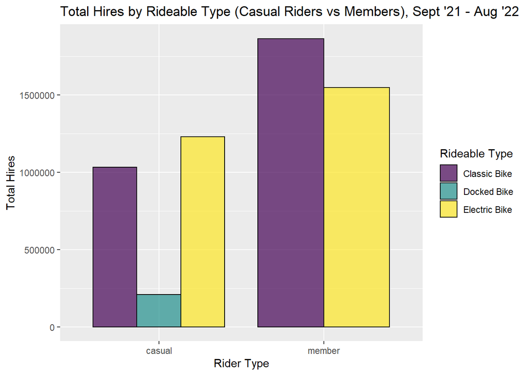

```r
#get mean ride duration for members vs casual riders by month
hires %>% group_by(member_casual) %>% count(rideable_type) %>%
  ggplot(aes(x=member_casual, y=n)) +

  geom_bar(aes(fill=rideable_type), position="dodge", stat="identity", width=0.8, alpha=0.7, colour="black") +
  ylab("Total Hires") +
  xlab("Rider Type") +
  labs(title="Total Hires by Rideable Type (Casual Riders vs Members), Sept '21 - Aug '22") +
  scale_fill_viridis(discrete = TRUE, name = "Rideable Type", labels = c("Classic Bike", "Docked Bike", "Electric Bike")) +
  scale_y_continuous()
```

The same data can be viewed as a pair of pie charts for comparison. This shows the creased preference for electric bikes with the Casual Riders compared to the Members.

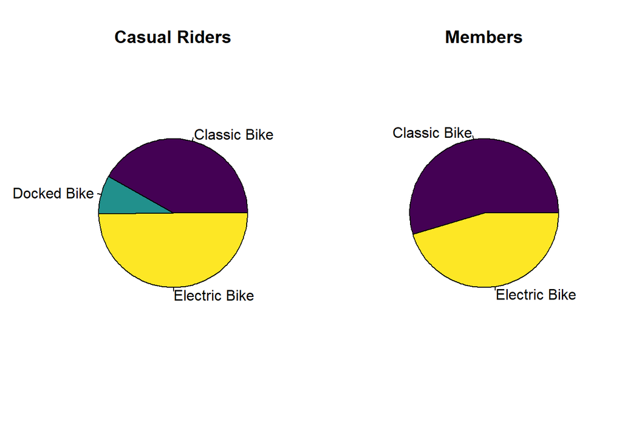

```r
casual_rideable_types <- hires %>% filter(member_casual=="casual") %>% count(rideable_type)
member_rideable_types <- hires %>% filter(member_casual=="member") %>% count(rideable_type)

par(mfrow=c(1,2))
pie(casual_rideable_types$n, labels=c("Classic Bike", "Docked Bike", "Electric Bike"), col=(viridis(3, option = "D")), main="Casual Riders")
pie(member_rideable_types$n, labels=c("Classic Bike", "Electric Bike"), col=(viridis(2, option = "D")), main="Members")
```

3. Casual riders make greater use of the Cyclstic service on Saturday and Sunday compared to the week, indicating this is more likely a recreational activity for casual riders, rather than a mode of commute.
4. Members tend to use the Cyclstic service more during the week and less on the weekend, indicating this is more likely a mode of commute for many members

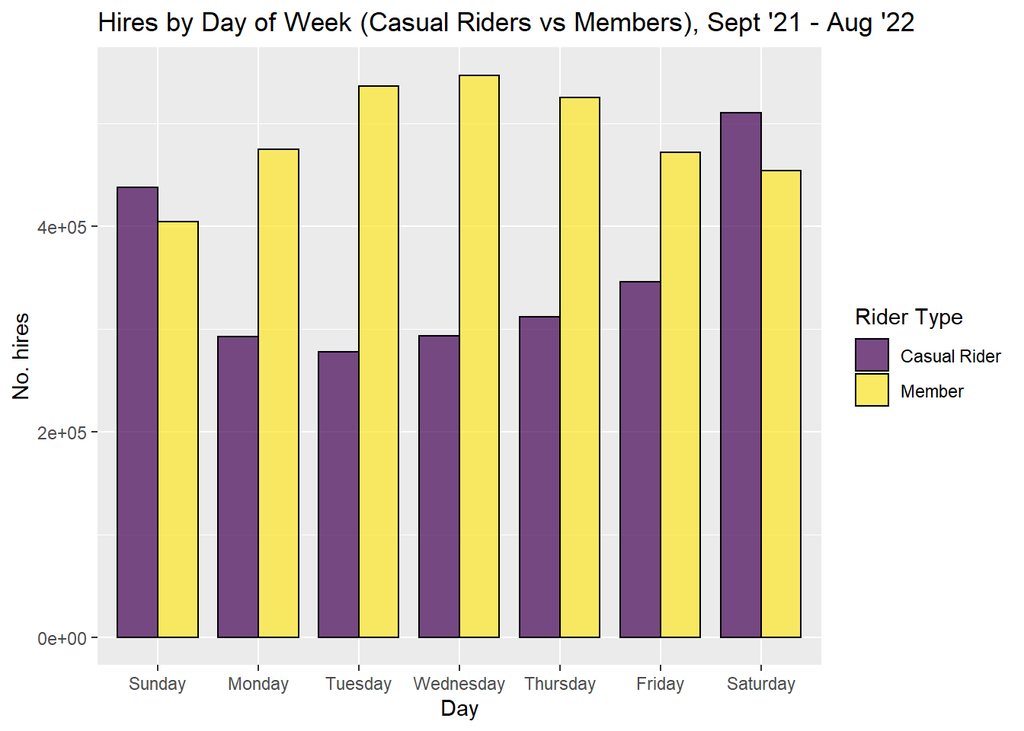

```r
hires %>%
  group_by(member_casual) %>%
  count(weekday) %>%

  ggplot( aes(weekday, n)) +
  geom_bar(aes(fill=member_casual),  position ="dodge", stat='identity', width=0.8, alpha=0.7, colour="black") +
  labs(title="Hires by Day of Week (Casual Riders vs Members), Sept '21 - Aug '22") +
  xlab("Day") +
  scale_fill_viridis(discrete = TRUE, name = "Rider Type", labels = c("Casual Rider", "Member")) +
  ylab("No. hires")+
  scale_y_continuous()
```

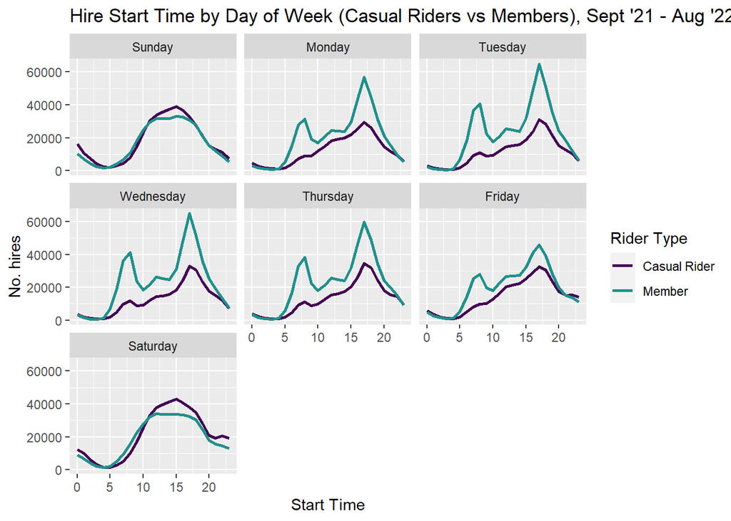

```r
hires %>%
  group_by(member_casual, weekday) %>%
  count(start_hour) %>%

  ggplot( aes(start_hour, n)) +
  geom_line(aes(color=member_casual),  stat='identity',size=1) +
  scale_colour_manual(values=viridis(3, option = "D"), name = "Rider Type", labels = c("Casual Rider", "Member")) +
  facet_wrap(~weekday) +
  labs(title="Hire Start Time by Day of Week (Casual Riders vs Members), Sept '21 - Aug '22") +
  xlab("Start Time") +
  ylab("No. hires")
```

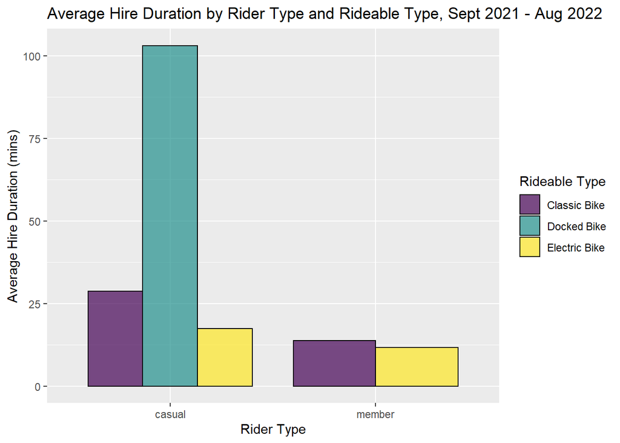

```r
#get mean ride duration for members vs casual riders by month
avg_duration_plot <- hires %>% group_by(member_casual, rideable_type) %>%
  summarise(avg_duration = mean(mins_hired)) %>%
  ggplot(aes(x=member_casual, y=avg_duration)) +

  geom_bar(aes(fill=rideable_type), position="dodge", stat="identity", width=0.8, alpha=0.7, colour="black") +
  ylab("Average Hire Duration (mins)") +
  xlab("Rider Type") +
  labs(title="Average Hire Duration by Rider Type and Rideable Type, Sept 2021 - Aug 2022") +
  scale_fill_viridis(discrete = TRUE, name = "Rideable Type", labels = c("Classic Bike", "Docked Bike", "Electric Bike")) +
  scale_y_continuous()
```

To inform the marketing strategy an analysis was undertaken to map the locations where casual riders were starting and ending their journeys. Marketing activities can target these locations for media campaigns using advertising boards in stations / billboards / bus stops etc..

```
## Using zoom = 14...
```

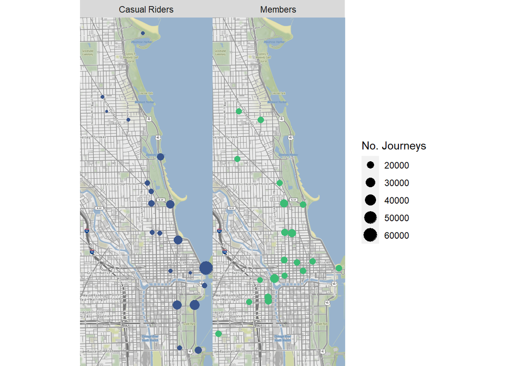

Busiest Stations for Casual Riders

| Station Name | Journeys | Long. | Lat. |
| --- | --- | --- | --- |
| Streeter Dr & Grand Ave | 60943 | -87.61204 | 41.89228 |
| DuSable Lake Shore Dr & Monroe St | 32717 | -87.61674 | 41.88096 |
| Millennium Park | 28030 | -87.62408 | 41.88103 |
| Michigan Ave & Oak St | 26677 | -87.62378 | 41.90096 |
| DuSable Lake Shore Dr & North Blvd | 25539 | -87.62680 | 41.91172 |
| Shedd Aquarium | 20865 | -87.61536 | 41.86723 |
| Theater on the Lake | 19522 | -87.63083 | 41.92628 |
| Wells St & Concord Ln | 17919 | -87.63466 | 41.91213 |
| Clark St & Armitage Ave | 14952 | -87.63628 | 41.91831 |
| Clark St & Lincoln Ave | 14732 | -87.63460 | 41.91569 |
| Dusable Harbor | 14573 | -87.61281 | 41.88698 |
| Indiana Ave & Roosevelt Rd | 14327 | -87.62304 | 41.86789 |
| Clark St & Elm St | 14320 | -87.63128 | 41.90297 |
| Wells St & Elm St | 14304 | -87.63432 | 41.90322 |
| Wabash Ave & Grand Ave | 12909 | -87.62676 | 41.89147 |
| Broadway & Barry Ave | 12749 | -87.64410 | 41.93758 |
| Clark St & Newport St | 12663 | -87.65468 | 41.94454 |
| Montrose Harbor | 12650 | -87.63818 | 41.96398 |
| New St & Illinois St | 12457 | -87.61862 | 41.89085 |
| Wilton Ave & Belmont Ave | 12347 | -87.65304 | 41.94018 |

Busiest Stations for Members

| Station Name | Journeys | Long. | Lat. |
| --- | --- | --- | --- |
| Kingsbury St & Kinzie St | 26472 | -87.63851 | 41.88918 |
| Clark St & Elm St | 23413 | -87.63128 | 41.90297 |
| Wells St & Concord Ln | 23102 | -87.63466 | 41.91213 |
| Wells St & Elm St | 20393 | -87.63432 | 41.90322 |
| Clinton St & Madison St | 19826 | -87.64107 | 41.88224 |
| Clinton St & Washington Blvd | 19685 | -87.64117 | 41.88338 |
| Wells St & Huron St | 18267 | -87.63436 | 41.89472 |
| Dearborn St & Erie St | 18159 | -87.62932 | 41.89399 |
| Broadway & Barry Ave | 18034 | -87.64410 | 41.93758 |
| St. Clair St & Erie St | 17922 | -87.62280 | 41.89435 |
| DuSable Lake Shore Dr & North Blvd | 17526 | -87.62680 | 41.91172 |
| Streeter Dr & Grand Ave | 17469 | -87.61204 | 41.89228 |
| Loomis St & Lexington St | 17448 | -87.66150 | 41.87219 |
| Wabash Ave & Grand Ave | 17286 | -87.62676 | 41.89147 |
| Wells St & Hubbard St | 16586 | -87.63427 | 41.88991 |
| Clark St & Armitage Ave | 16449 | -87.63628 | 41.91831 |
| Wilton Ave & Belmont Ave | 16382 | -87.65304 | 41.94018 |
| Green St & Madison St | 16322 | -87.64879 | 41.88189 |
| Sheffield Ave & Fullerton Ave | 16214 | -87.65371 | 41.92560 |
| Desplaines St & Kinzie St | 16079 | -87.64445 | 41.88872 |

## Headlines & Recommendations

Focus on the following three characteristics of Casual Riders’ behaviours when marketing to them, as they are dinstinct to existing Members’ characteristics and behaviours. - Casual riders tend to hire electric bikes and the ‘docked bike’ category more often compared to existing members. - Casual riders use the service on the weekend more than during the week, with highest activity between 10am and 6pm - Casual riders’ most popular docking stations tend to be in/adjacent to recreational spaces; Members’ most popular stations tend to be situated in built up areas